# Stat 133 Spring 2015

Lecture 3 January 28th 2015

Slightly modified from Chris Paciorek’s 2014 R bootcamp, UC Berkeley

# R as a calculator

```r
2 + 2 # add numbers
```

```
## [1] 4
```

```r
2 * pi # multiply by a constant
```

```
## [1] 6.283185
```

```r
7 + runif(1) # add a random number
```

```
## [1] 7.94187
```

```r
3^4 # powers
```

```
## [1] 81
```

```r
sqrt(4^4) # functions
```

```
## [1] 16
```

```r
log(10)
```

```
## [1] 2.302585
```

```r
log(100, base = 10)
```

```
## [1] 2
```

```r
23 %/% 2
```

```
## [1] 11
```

```r
23 %% 2
```

```
## [1] 1
```

```r
# scientific notation
5000000000 * 1000
```

```
## [1] 5e+12
```

```r
5e9 * 1e3
```

```
## [1] 5e+12
```

Think of a mathematical operation you need - can you guess how to do it in R?

# Assigning values to R objects

A key action in R is to store values in the form of R objects, and to examine the value of R objects.

```r
val <- 3
val
```

```
## [1] 3
```

```r
print(val)
```

```
## [1] 3
```

```r
Val <- 7 # case-sensitive!
print(c(val, Val))
```

```
## [1] 3 7
```

We can work with (and store) sequences and repetitions

```r
mySeq <- 1:6
mySeq
```

```
## [1] 1 2 3 4 5 6
```

```r
myOtherSeq <- seq(1.1, 11.1, by = 2)
myOtherSeq
```

```
## [1]  1.1  3.1  5.1  7.1  9.1 11.1
```

```r
length(myOtherSeq)
```

```
## [1] 6
```

```r
fours <- rep(4, 6)
fours
```

```
## [1] 4 4 4 4 4 4
```

```r
# This is a comment: here is an example of non-numeric data
depts <- c('espm', 'pmb', 'stats')
depts
```

```
## [1] "espm"  "pmb"   "stats"
```

If we don’t assign the output of a command to an object, we haven’t saved it for later use.

R gives us a lot of flexibility (within certain rules) for assigning to (parts of) objects from (parts of) other objects.

# How to be [lazy](http://dilbert.com/strips/comic/2005-05-29/)

If you’re starting to type something you’ve typed before, or the long name of an R object or function, STOP! You likely don’t need to type all of that.

- Tab completion
- Command history
  - up/down arrows
  - Ctrl-{up arrow} or Command-{up arrow}
- RStudio: select a line or block for execution
- Put your code in a file and use `source()`. For example: `source('myRcodeFile.R')`

# Vectors in R

The most basic form of an R object is a vector. In fact, individual (scalar) values are vectors of length one.

We can concatenate values into a vector with `c()`.

```r
# numeric vector
nums <- c(1.1, 3, -5.7)
devs <- rnorm(5)
devs
```

```
## [1] -1.7866569 -0.6279685 -0.2851314 -0.9018921  1.5654340
```

```r
# integer vector
ints <- c(1L, 5L, -3L) # force storage as integer not decimal number
# 'L' is for 'long integer' (historical)

idevs <- sample(ints, 100, replace = TRUE)

# character vector
chars <- c('hi', 'hallo', "mother's", 'father\'s',
   "She said, 'hi'", "He said, \"hi\"" )
chars
```

```
## [1] "hi"              "hallo"           "mother's"        "father's"
## [5] "She said, 'hi'"  "He said, \"hi\""
```

```r
cat(chars, sep = "\n")
```

```
## hi
## hallo
## mother's
## father's
## She said, 'hi'
## He said, "hi"
```

```r
# logical vector
bools <- c(TRUE, FALSE, TRUE)
bools
```

```
## [1]  TRUE FALSE  TRUE
```

# Working with indices and subsets

```r
vals <- seq(2, 12, by = 2)
vals
```

```
## [1]  2  4  6  8 10 12
```

```r
vals[3]
```

```
## [1] 6
```

```r
vals[3:5]
```

```
## [1]  6  8 10
```

```r
vals[c(1, 3, 6)]
```

```
## [1]  2  6 12
```

```r
vals[-c(1, 3, 6)]
```

```
## [1]  4  8 10
```

```r
vals[c(rep(TRUE, 3), rep(FALSE, 2), TRUE)]
```

```
## [1]  2  4  6 12
```

We can substitute values into vectors

```r
vals[4] <- -35
vals[1:2] <- 0

vals <- rnorm(100)
# How does R process these next subset operations?
vals[vals < 0] <- 0
vals[1:8]
```

```
## [1] 0.28918424 0.00000000 0.58495573 0.13768514 1.23174108 0.01081166
## [7] 0.24983163 0.00000000
```

```r
set.seed(0)  # make random number generation repeatable
vals <- rnorm(100)
extremes <- vals[vals > 3]
extremes
```

```
## numeric(0)
```

```r
# what happened?
```

# Vectorized calculations and comparisons

At the core of R is the idea of doing calculations on entire vectors.

```r
vec1 <- sample(1:5, 10, replace = TRUE)
vec2 <- sample(1:5, 10, replace = TRUE)
vec1
```

```
##  [1] 4 2 2 3 2 1 3 3 1 2
```

```r
vec2
```

```
##  [1] 4 5 1 4 5 5 2 4 5 5
```

```r
vec1 + vec2
```

```
##  [1] 8 7 3 7 7 6 5 7 6 7
```

```r
vec1^vec2
```

```
##  [1] 256  32   2  81  32   1   9  81   1  32
```

```r
vec1 >= vec2
```

```
##  [1]  TRUE FALSE  TRUE FALSE FALSE FALSE  TRUE FALSE FALSE FALSE
```

```r
vec1 <= 3
```

```
##  [1] FALSE  TRUE  TRUE  TRUE  TRUE  TRUE  TRUE  TRUE  TRUE  TRUE
```

```r
vec1 == vec2
```

```
##  [1]  TRUE FALSE FALSE FALSE FALSE FALSE FALSE FALSE FALSE FALSE
```

```r
vec1 != vec2
```

```
##  [1] FALSE  TRUE  TRUE  TRUE  TRUE  TRUE  TRUE  TRUE  TRUE  TRUE
```

```r
# careful:
vec1 = vec2
identical(vec1, vec2)
```

```
## [1] TRUE
```

An important related concept is that of recycling

```r
vec3 <- sample(1:5, 5, replace = TRUE)
vec4 <- sample(1:5, 3, replace = TRUE)
vec1
```

```
##  [1] 4 5 1 4 5 5 2 4 5 5
```

```r
vec3
```

```
## [1] 2 2 1 2 3
```

```r
vec4
```

```
## [1] 5 3 2
```

```r
vec1 + vec3
```

```
##  [1] 6 7 2 6 8 7 4 5 7 8
```

```r
vec1 + vec4
```

```
##  [1]  9  8  3  9  8  7  7  7  7 10
```

**Question**: Tell me what’s going on. What choices were made by the R developers?

# R is a functional language

- Operations are carried out with functions. Functions take objects as inputs and return objects as outputs.
- An analysis can be considered a pipeline of function calls, with output from a function used later in a subsequent operation as input to another function.
- Functions themselves are objects:

```r
sum
```

```
## function (..., na.rm = FALSE)  .Primitive("sum")
```

```r
class(sum)
```

```
## [1] "function"
```

- We can embed function calls:

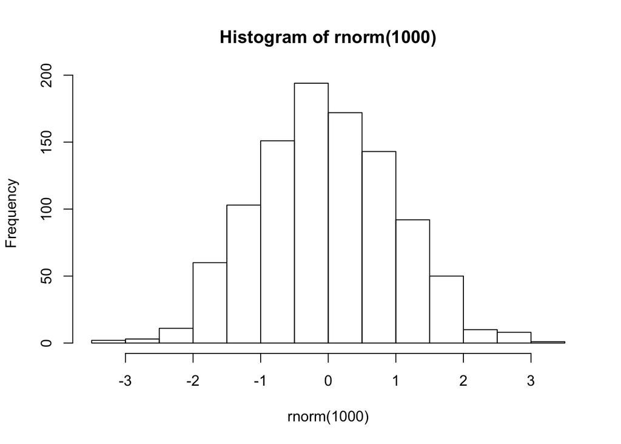

```r
hist(rnorm(1000))
```

# Getting help about a function

To get information about a function you know exists, use `help` or `?`, e.g., `?lm`. For information on a general topic, use `help.search`, `apropos` or `??`

```r
help(lm)
?lm
?log
help.search('regression')
# ??'regr' # take out the '#' to demo live - there's an issue with Markdown processing...
```

# Basic kinds of R objects

Vectors are not the only kinds of R objects.

### Vectors

Vectors of various types (numeric (i.e., decimal/floating point/double), integer, boolean, character), all items must be of the same type

### Matrices

Matrices of various types, all items must be of the same type

```r
mat <- matrix(rnorm(9), nrow = 3)
t(mat) %*% mat
```

```
##           [,1]      [,2]      [,3]
## [1,]  1.620910  1.650292 -1.223115
## [2,]  1.650292  1.954438 -1.506820
## [3,] -1.223115 -1.506820  4.047234
```

```r
dim(mat)
```

```
## [1] 3 3
```